# STATSBOMB Shots Metric

Kareem Tarek

## Preparing The Data

```r
# First I load the file and assign it to a variable
shots <- read.csv2('/Users/kareemtarek/Desktop/Statsbomb/shots.csv',header = TRUE, sep = ",")
# I then extract only the columns we need for showcasing
shots_filtered <- shots %>%
  select(id, play_pattern.name, position.name, shot.statsbomb_xg, shot.technique.name, shot.outcome.name, shot.type.name, shot_distance_x,
opponents.within.1m)  %>%
# Now I filter rows to get only the goals.
filter(shot.outcome.name == 'Goal')
```

**Note that i have a limitation of working with only 2,816 initial observations, and 310 observation after filtering, that’s because only data for a single season is provided**

## Validating The Data

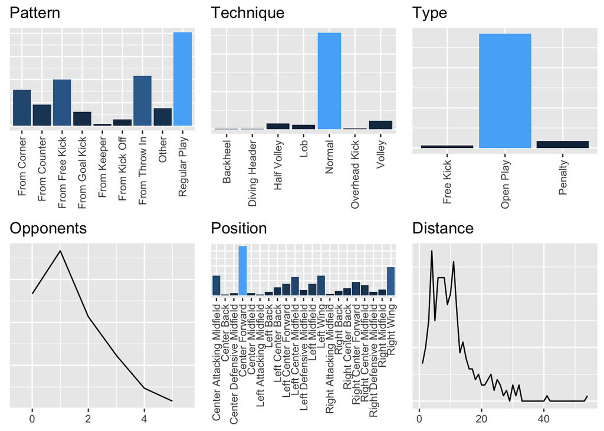

```r
# Now I test the correlation between shot.outcome.name variable and other variables, to see if they contribute to scoring a goal
  v1 <- ggplot(data=shots_filtered, aes(x= play_pattern.name)) +
     geom_bar(aes(fill=..count..)) +
        ggtitle("Pattern") +
        theme(legend.position="none",
              axis.text.x = element_text(angle = 90, vjust = 0.5, hjust=1),
              axis.title.x=element_blank(),
              axis.title.y=element_blank(),
              axis.text.y=element_blank(),
              axis.ticks.y=element_blank())

 v2 <- ggplot(data=shots_filtered, aes(x= position.name)) +
     geom_bar(aes(fill=..count..)) +
        ggtitle("Position") +
        theme(legend.position="none",
              axis.text.x = element_text(angle = 90, vjust = 0.5, hjust=1),
              axis.title.x=element_blank(),
              axis.title.y=element_blank(),
              axis.text.y=element_blank(),
              axis.ticks.y=element_blank())

  v3 <- ggplot(data=shots_filtered, aes(x= shot.technique.name)) +
     geom_bar(aes(fill=..count..)) +
        ggtitle("Technique") +
        theme(legend.position="none",
              axis.text.x = element_text(angle = 90, vjust = 0.5, hjust=1),
              axis.title.x=element_blank(),
              axis.title.y=element_blank(),
              axis.text.y=element_blank(),
              axis.ticks.y=element_blank())

   v4 <- ggplot(data=shots_filtered, aes(x= shot.type.name)) +
     geom_bar(aes(fill=..count..)) +
        ggtitle("Type") +
        theme(legend.position="none",
              axis.text.x = element_text(angle = 90, vjust = 0.5, hjust=1),
              axis.title.x=element_blank(),
              axis.title.y=element_blank(),
              axis.text.y=element_blank(),
              axis.ticks.y=element_blank())

    v5 <-  ggplot(data=shots_filtered, aes(x=as.numeric(shot_distance_x))) +
        geom_line(aes(fill=..count..), stat="bin", binwidth=1) +
        ggtitle("Distance") +
        theme(
            axis.title.x=element_blank(),
            axis.title.y=element_blank(),
            axis.text.y=element_blank(),
            axis.ticks.y=element_blank())

    v6 <- ggplot(data=shots_filtered, aes(x=opponents.within.1m)) +
        geom_line(aes(fill=..count..), stat="bin", binwidth=1) +
        ggtitle("Opponents") +
        theme(
            axis.title.x=element_blank(),
            axis.title.y=element_blank(),
            axis.text.y=element_blank(),
            axis.ticks.y=element_blank())

 ggarrange(v1, v3, v4, v6, v2, v5,
          ncol = 3, nrow = 2,
          common.legend = F)
```

### Key Observations And Next Steps

1. Nearly all of the goals were scored with Technique=Normal and Shot Type=Open Play, so it is easier exclude them in the next steps (we know that a a goal is oftenly scored with a normal shot, in an open play)
2. Secondly, for both distance and and number of opponents surrounding the player, it’s clear that they having an inversely proportional relationship with scoring.
3. Lastly Shooting pattern and player’s position also impacts scoring a goal, so we’d include them as well.

```r
# Removing unwanted columns
shots_filtered <- shots_filtered %>%
  select(id, play_pattern.name, position.name, shot.statsbomb_xg, shot.outcome.name, shot_distance_x,
opponents.within.1m)
```

## Constructing The Metric

My approach to constructing the metric is using probability. First, i’d give each value of each attribute a probability. For instance in 10 records 8 of them the position was center, so center value is given a probability 0.8. In a single record, I’d combine (multiply) the probability from each value to get our metric. we’d call it score.probability.

Example: score.probability = probability_regular_play * probability_position_value_center * probability_distance_0.. etc.

```r
# Removing unwanted columns
shots_final <- shots_filtered %>%
  group_by(play_pattern.name) %>%
  mutate(play_pattern.name.p =  n()/nrow(shots_filtered))

# Repeat for other variables
shots_final <- shots_final %>%
  group_by(position.name) %>%
  mutate(position.name.p =  n()/nrow(shots_filtered))

shots_final <- shots_final %>%
  group_by(shot_distance_x) %>%
  mutate(shot_distance_x.p =  n()/nrow(shots_filtered))

shots_final <- shots_final %>%
  group_by(opponents.within.1m) %>%
  mutate(opponents.within.1m.p =  n()/nrow(shots_filtered))

# Finally we calculate our new metric using the combination of the newly formed probabilities
shots_final <- shots_final %>%
    rowwise() %>%
    mutate(score_probability= play_pattern.name.p * position.name.p * shot_distance_x.p * opponents.within.1m.p)
```

### Testing The Metric

#### How does this new field compare to StatsBomb’s xG (expected goals) field?

They both use the variables provided to come up with a probability whether a shot is going to be a Goal or not

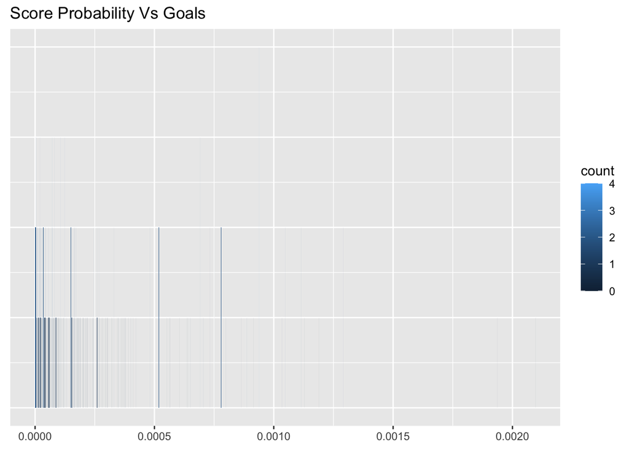

```r
# Now i have the scoring metric, I join it back with the original data set.
shots_final <- shots_final %>%
  select(id, score_probability)

shots_merged <- merge(x=shots, y=shots_final, by = "id", all.x = TRUE)

# Replace NA values in score_probability column with 0
shots_merged$score_probability[is.na(shots_merged$score_probability)] <- 0

### Goals vs the metric (Goals here represents the team performance )
shots_merged_goals <- shots_merged %>%
filter(shot.outcome.name == 'Goal')

ggplot(data=shots_merged_goals, mapping = aes(x=score_probability)) +
        geom_bar(aes(fill=..count..), stat="bin", binwidth=0.0000001) +
        ggtitle("Score Probability Vs Goals") +
        theme(
            axis.title.x=element_blank(),
            axis.title.y=element_blank(),
            axis.text.y=element_blank(),
            axis.ticks.y=element_blank())
```

```r
# Unfortunately for each probability there ain't as many observations, that's because only data for 1 season was provided, to repeat the process for more seasons
```